# R Notebook

# Normalizacion Min-Max

Los valores son transformado en forma lineal a un rango pre-espeficifados

Para la transformacion Z

RMSE : Error cuadratico medio

La puntuacion Z,

No son modelos casuales la relacion entre Xe Y, solo se menciona que hay asociacion entre X e Y

# Transformacion

```r
install.packages("Fahrmeir")
```

# ————————————————————————

# Ejemplo: Cr?ditos de Banco Alem?n

#————————————————————————-#

# Se plantean 3 tipos de transformaciones que no afectan el comportamiento

# de los datos

```r
library(Fahrmeir)
data(credit)
help(credit)

head(credit)
```

|  | Y | Cuenta | Mes | Ppag | Uso | DM | Sexo | Estc |
| --- | --- | --- | --- | --- | --- | --- | --- | --- |
| 1 | buen | no | 18 | pre buen pagador | privado | 1049 | mujer | vive solo |
| 2 | buen | no | 9 | pre buen pagador | profesional | 2799 | hombre | no vive solo |
| 3 | buen | bad running | 12 | pre buen pagador | profesional | 841 | mujer | vive solo |
| 4 | buen | no | 12 | pre buen pagador | profesional | 2122 | hombre | no vive solo |
| 5 | buen | no | 12 | pre buen pagador | profesional | 2171 | hombre | no vive solo |
| 6 | buen | no | 10 | pre buen pagador | profesional | 2241 | hombre | no vive solo |

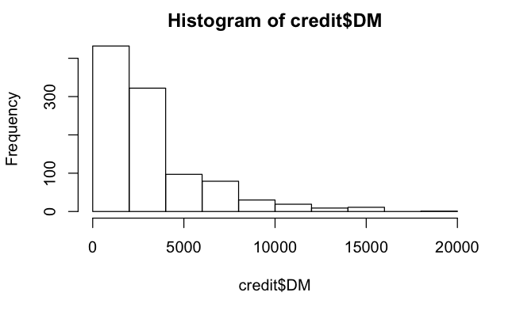

```r
hist(credit$DM)
```

```r
#Z-score
library(reshape)
credit$zDM<-rescaler(x=credit$DM,type="sd")
#credit$DM_Zscore<-scale(x=credit$DM)
```

# Transformacion Min-Max

Se aplica la transformacion , con 3 parametros

```r
library(DMwR)
credit$mmDM<-ReScaling(x = credit$DM, t.mn=0, t.mx=1)
```

Se aplica una transformacion lineal y se mantiene

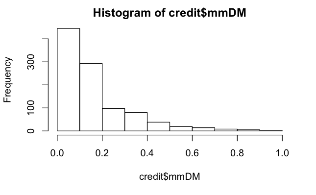

```r
hist(credit$mmDM)
```

#Escalamiento decimal

Se usa para transformar datos entre -1 a 1

datos = -20, 0, 1, 30

la transformacion no deberia hacerse cuando se realiza una hipotesis. En el caso que se quiera hacer prediccion, se puede usar la transformacion.

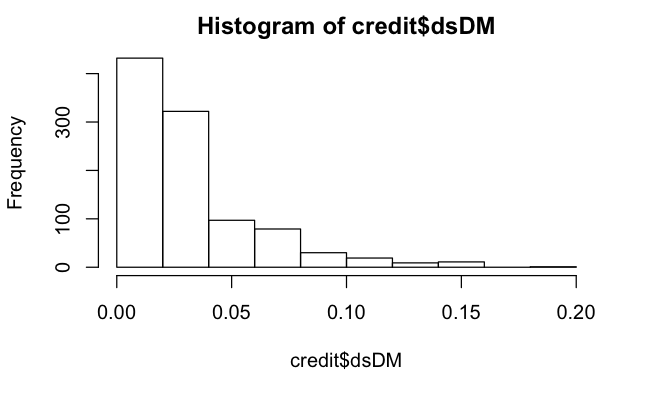

```r
maxvect = max(abs(credit$DM)) # Obtiene el max nro de digitos
kvector = ceiling(log10(maxvect)) #
scalefactor = 10^kvector
credit$dsDM= credit$DM/scalefactor
hist(credit$dsDM)
```

# Transformacion no lineal cuando se desea que la relacion de los datos centrales se mantengan lineales y los extremos de forma no lineal

#Sigmoidal

varia entre -1 y 1 los valores

```r
credit$sigDM = (1 - exp(-rescaler(x=credit$DM)))/(1 + exp(-rescaler(x=credit$DM)))
```

```r
#Haciendo plots para ver el efecto de la normalizacion
par(mfrow=c(1,2))
plot(sort(credit$DM))
plot(sort(credit$sigDM))
```

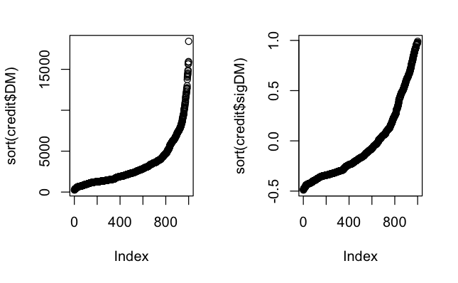

```r
par(mfrow=c(1,1))
```

La cola desaparece

#Softmax varia entre 0 y 1 los valores

```r
#credit$softDM<-DMwR::SoftMax(credit$DM,lambda=2*pi)
credit$softDM2 = 1/(1 + exp(-rescaler(x=credit$DM)))
```

Se aplica cuando se quiera usar un score

```r
summary(credit)
```

```
    Y                Cuenta         Mes
 buen:700   no          :274   Min.   : 4.0
 mal :300   good running:394   1st Qu.:12.0
            bad running :332   Median :18.0
                               Mean   :20.9
                               3rd Qu.:24.0
                               Max.   :72.0
               Ppag              Uso            DM
 pre buen pagador:911   privado    :657   Min.   :  250
 pre mal pagador : 89   profesional:343   1st Qu.: 1366
                                          Median : 2320
                                          Mean   : 3271
                                          3rd Qu.: 3972
                                          Max.   :18424
     Sexo               Estc          zDM
 mujer :402   no vive solo:640   Min.   :-1.0703
 hombre:598   vive solo   :360   1st Qu.:-0.6751
                                 Median :-0.3372
                                 Mean   : 0.0000
                                 3rd Qu.: 0.2483
                                 Max.   : 5.3681
      mmDM              dsDM             sigDM
 Min.   :0.00000   Min.   :0.00250   Min.   :-0.48932
 1st Qu.:0.06138   1st Qu.:0.01366   1st Qu.:-0.32531
 Median :0.11387   Median :0.02320   Median :-0.16701
 Mean   :0.16624   Mean   :0.03271   Mean   :-0.03729
 3rd Qu.:0.20481   3rd Qu.:0.03972   3rd Qu.: 0.12354
 Max.   :1.00000   Max.   :0.18424   Max.   : 0.99072
    softDM2
 Min.   :0.2553
 1st Qu.:0.3373
 Median :0.4165
 Mean   :0.4814
 3rd Qu.:0.5618
 Max.   :0.9954
```

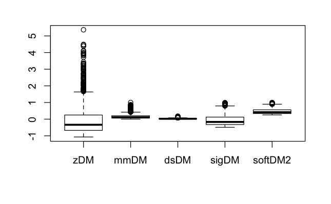

```r
#Gr?fico de comparaci?n
boxplot(credit[,c(9,10,11,12,13)])
```

Se observa que las transformaciones Sigmoidal comprimen las colas